# FINAL CAPSTONE PROJECT 2

- In this project, we will visualize stock prices using Seaborn and Matplotlib. The 4 stocks that will be visualized are JP Morgan Chase (JP), Procter and Gamble (P&G) (PG), Apple (AAPL) and United Airlines (UAL).
- Using the “stock_daily_prices.csv” and “stocks_daily_returns.csv” included in the attachment, write Python scripts to perform the following tasks:
  - Import both data using Pandas.
  - Using Matplotlib, plot a lineplot showing all daily prices of 4 stocks in one figure.
  - Using Matplotlib, plot the daily prices of the 4 stocks in several subplots.
  - Using Matplotlib, visualize 4 plots on subplots next to each other (all figures in one row).
  - Using Matplotlib, visualize a scatterplot between Apple's daily returns and JP Morgan's daily returns.
  - Using Seaborn, visualize a scatterplot between Apple's daily returns and JP Morgan's daily returns.
  - Assume that you decide to be bullish on AAPL and you allocate 70% of your assets in it. You also decide to divide your remaining assets equally among other stocks (JPM, PG, and UAL). Using Matplotlib, plot a piechart showing these allocations. Use the ‘explode’ attribute to increase separation between AAPL and the rest of the portfolio.
  - Using Matplotlib, plot histograms for United Airlines and P&G returns using 40 bins in red. Show the average and Standard deviation for both stocks above the image. What do you conclude from the graph?
  - Using Seaborn, plot a heatmap showing the correlation between daily stock returns. Comment on the correlation between UAL and P&G.
  - Create a 3D plot showing all daily returns from JPM, AAPL, and UAL [need to figure out how to do this personally].

```python
import pandas as pd
import matplotlib.pyplot as plt
import seaborn as sns
%matplotlib inline
```

```python
daily_prices_df = pd.read_csv('stocks_daily_prices.csv')
daily_returns_df = pd.read_csv('stocks_daily_returns.csv')
```

```python
daily_prices_df
```

|  | Date | AAPL | JPM | PG | UAL |
| --- | --- | --- | --- | --- | --- |
| 0 | 1/2/2008 | 5.949703 | 29.448614 | 47.058838 | 29.915234 |
| 1 | 1/3/2008 | 5.952452 | 29.246094 | 47.058838 | 29.690800 |
| 2 | 1/4/2008 | 5.498071 | 28.582682 | 46.870098 | 31.000002 |
| 3 | 1/7/2008 | 5.424478 | 28.868999 | 47.175980 | 29.180000 |
| 4 | 1/8/2008 | 5.229351 | 27.723747 | 47.299629 | 24.389999 |
| ... | ... | ... | ... | ... | ... |
| 3637 | 6/13/2022 | 131.880005 | 115.989998 | 138.149994 | 37.020000 |
| 3638 | 6/14/2022 | 132.759995 | 114.059998 | 133.839996 | 36.990002 |
| 3639 | 6/15/2022 | 135.429993 | 115.410004 | 132.509995 | 37.889999 |
| 3640 | 6/16/2022 | 130.059998 | 113.430000 | 133.320007 | 34.779999 |
| 3641 | 6/17/2022 | 131.559998 | 113.029999 | 132.360001 | 36.279999 |

3642 rows × 5 columns

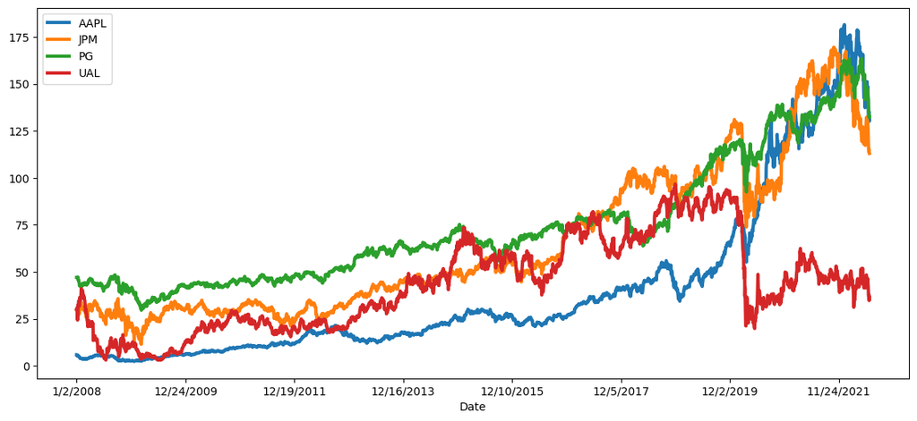

```python
daily_prices_df.plot(x = 'Date', y = [ 'AAPL', 'JPM', 'PG', 'UAL'], linewidth = 3, figsize = (14,6))
```

[output not shown]

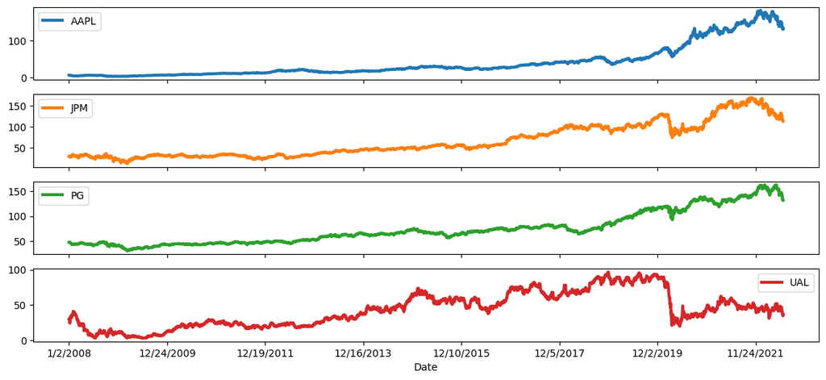

```python
daily_prices_df.plot(x = 'Date', y = [ 'AAPL', 'JPM', 'PG', 'UAL'], linewidth = 3, figsize = (14,6), subplots=True)
```

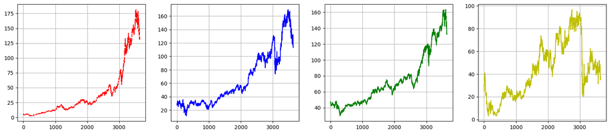

```python
plt.figure(figsize=(20,4))

plt.subplot(1,4,1)
plt.plot(daily_prices_df['AAPL'], 'r--')
plt.grid()

plt.subplot(1,4,2)
plt.plot(daily_prices_df['JPM'], 'b')
plt.grid()

plt.subplot(1,4,3)
plt.plot(daily_prices_df['PG'], 'g')
plt.grid()

plt.subplot(1,4,4)
plt.plot(daily_prices_df['UAL'], 'y')
plt.grid()
```

```python
daily_returns_df
```

|  | Date | AAPL | JPM | PG | UAL |
| --- | --- | --- | --- | --- | --- |
| 0 | 1/2/2008 | 0.000000 | 0.000000 | 0.000000 | 0.000000 |
| 1 | 1/3/2008 | 0.046203 | -0.687708 | 0.000000 | -0.750233 |
| 2 | 1/4/2008 | -7.633517 | -2.268378 | -0.401072 | 4.409454 |
| 3 | 1/7/2008 | -1.338518 | 1.001718 | 0.652615 | -5.870973 |
| 4 | 1/8/2008 | -3.597157 | -3.967066 | 0.262103 | -16.415356 |
| ... | ... | ... | ... | ... | ... |
| 3637 | 6/13/2022 | -3.828484 | -2.977838 | -2.677001 | -10.058308 |
| 3638 | 6/14/2022 | 0.667265 | -1.663937 | -3.119796 | -0.081034 |
| 3639 | 6/15/2022 | 2.011147 | 1.183593 | -0.993725 | 2.433084 |
| 3640 | 6/16/2022 | -3.965145 | -1.715625 | 0.611284 | -8.207972 |
| 3641 | 6/17/2022 | 1.153314 | -0.352642 | -0.720077 | 4.312824 |

3642 rows × 5 columns

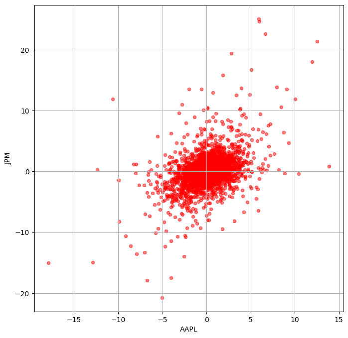

```python
daily_returns_df.plot.scatter('AAPL', 'JPM', grid=True, alpha=0.5, figsize=(8,8), color = 'r')
```

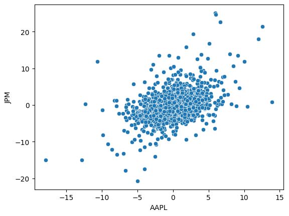

```python
sns.scatterplot(data=daily_returns_df, x='AAPL', y='JPM')
```

```python
data = {'alokasi %' : [70,10,10,10]}
index = ['AAPL','JPM','PG','UAL']
bullish_pd = pd.DataFrame(data, index)

bullish_pd
```

|  | alokasi % |
| --- | --- |
| AAPL | 70 |
| JPM | 10 |
| PG | 10 |
| UAL | 10 |

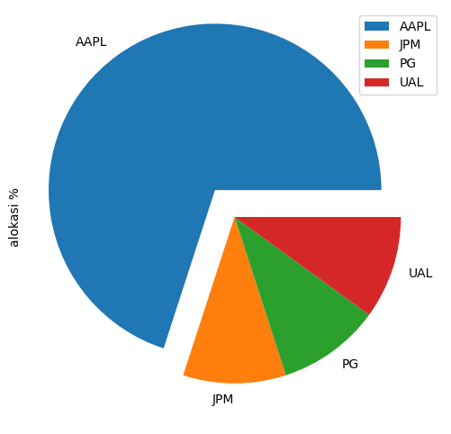

```python
bullish_pd.plot.pie(y='alokasi %', explode = (0.2,0,0,0), figsize=(6,6))
```

```python
daily_returns_df
```

|  | Date | AAPL | JPM | PG | UAL |
| --- | --- | --- | --- | --- | --- |
| 0 | 1/2/2008 | 0.000000 | 0.000000 | 0.000000 | 0.000000 |
| 1 | 1/3/2008 | 0.046203 | -0.687708 | 0.000000 | -0.750233 |
| 2 | 1/4/2008 | -7.633517 | -2.268378 | -0.401072 | 4.409454 |
| 3 | 1/7/2008 | -1.338518 | 1.001718 | 0.652615 | -5.870973 |
| 4 | 1/8/2008 | -3.597157 | -3.967066 | 0.262103 | -16.415356 |
| ... | ... | ... | ... | ... | ... |
| 3637 | 6/13/2022 | -3.828484 | -2.977838 | -2.677001 | -10.058308 |
| 3638 | 6/14/2022 | 0.667265 | -1.663937 | -3.119796 | -0.081034 |
| 3639 | 6/15/2022 | 2.011147 | 1.183593 | -0.993725 | 2.433084 |
| 3640 | 6/16/2022 | -3.965145 | -1.715625 | 0.611284 | -8.207972 |
| 3641 | 6/17/2022 | 1.153314 | -0.352642 | -0.720077 | 4.312824 |

3642 rows × 5 columns

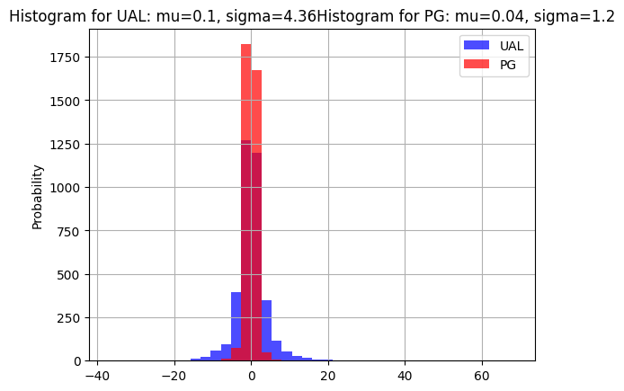

```python
mu1 = round(daily_returns_df['UAL'].mean(), 2) # mean of distribution
sigma1 = round(daily_returns_df['UAL'].std(), 2) # standard deviation of distribution

mu2 = round(daily_returns_df['PG'].mean(), 2) # mean of distribution
sigma2 = round(daily_returns_df['PG'].std(), 2) # standard deviation of distribution

num_bins = 40

plt.figure(figsize = (20, 15))

daily_returns_df[['UAL','PG']].plot.hist(bins = num_bins, color = ('b','r'), alpha = 0.7)

plt.grid()
plt.ylabel('Probability')
plt.title('Histogram for UAL: mu=' + str(mu1) + ', sigma=' + str(sigma1) + 'Histogram for PG: mu=' + str(mu2) + ', sigma=' + str(sigma2))
```

```python
daily_prices_df
```

[output not shown]

3642 rows × 4 columns

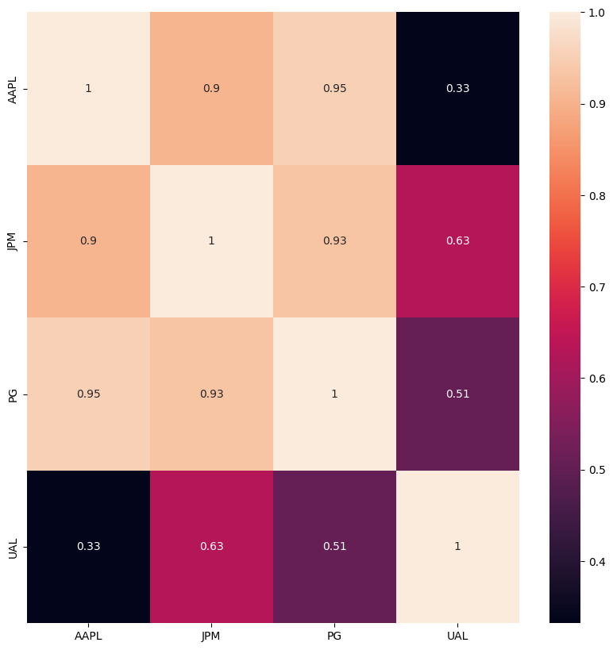

```python
plt.figure(figsize=(10,10))
# deletedate = daily_prices_df.drop('Date',axis='columns', inplace=True)
cm= daily_prices_df.corr()
sns.heatmap(cm,annot=True)
```

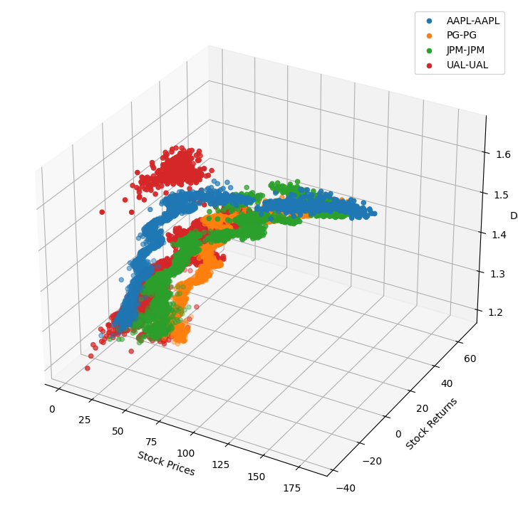

```python
import matplotlib.pyplot as plt
from mpl_toolkits.mplot3d import Axes3D
import pandas as pd

# Convert 'Date' column to datetime
daily_prices_df['Date'] = pd.to_datetime(daily_prices_df['Date'])

fig = plt.figure(figsize=(20, 15))
ax1 = fig.add_subplot(121, projection='3d')

# Convert 'Date' to numerical representation
z = pd.to_numeric(daily_prices_df['Date'])
x_columns = ['AAPL', 'PG', 'JPM', 'UAL']
y_columns = ['AAPL', 'PG', 'JPM', 'UAL']

for x_col, y_col in zip(x_columns, y_columns):
    x = daily_prices_df[x_col].astype(float)  # Ensure data is numerical
    y = daily_returns_df[y_col].astype(float)  # Ensure data is numerical
    ax1.scatter(x, y, zs=z, label=f'{x_col}-{y_col}')

ax1.set_xlabel('Stock Prices')
ax1.set_ylabel('Stock Returns')
ax1.set_zlabel('Date')
ax1.legend()

plt.show()
```

```python
daily_returns_df[['AAPL', 'PG', 'JPM', 'UAL']]
```

|  | AAPL | PG | JPM | UAL |
| --- | --- | --- | --- | --- |
| 0 | 0.000000 | 0.000000 | 0.000000 | 0.000000 |
| 1 | 0.046203 | 0.000000 | -0.687708 | -0.750233 |
| 2 | -7.633517 | -0.401072 | -2.268378 | 4.409454 |
| 3 | -1.338518 | 0.652615 | 1.001718 | -5.870973 |
| 4 | -3.597157 | 0.262103 | -3.967066 | -16.415356 |
| ... | ... | ... | ... | ... |
| 3637 | -3.828484 | -2.677001 | -2.977838 | -10.058308 |
| 3638 | 0.667265 | -3.119796 | -1.663937 | -0.081034 |
| 3639 | 2.011147 | -0.993725 | 1.183593 | 2.433084 |
| 3640 | -3.965145 | 0.611284 | -1.715625 | -8.207972 |
| 3641 | 1.153314 | -0.720077 | -0.352642 | 4.312824 |

3642 rows × 4 columns